# UTS Supervised Learning

Rafly Priyantama Ramadhan Bagaskara

2025-10-19

# Studi Kasus: Audit dan Optimalisasi Model Gaji di PT. Digital Cemerlang

## Latar Belakang

Tim data internal PT. Digital Cemerlang telah mencoba membangun sebuah model untuk memprediksi gaji karyawan (Gaji_Bulanan) berdasarkan 20 faktor lainnya. Namun, hasil model awal mereka sangat meragukan. Meskipun model tersebut memiliki kemampuan prediksi yang tampak tinggi, koefisien (pengaruh) dari beberapa variabel kunci tidak stabil dan seringkali bertentangan dengan logika bisnis. Terdapat kecurigaan kuat bahwa ada masalah mendasar dalam data atau metode yang digunakan.

Anda bertindak sebagai konsultan independen yang ditugaskan untuk melakukan audit menyeluruh. Tugas Anda adalah mengidentifikasi sumber masalah, membangun model alternatif yang lebih valid dan andal, serta memberikan rekomendasi akhir kepada manajemen.

## Tujuan

Mendiagnosis kelemahan model linier standar pada dataset yang diberikan, menerapkan pendekatan pemodelan yang sesuai untuk memperbaiki masalah tersebut, dan memilih model final terbaik yang seimbang antara akurasi prediksi dan validitas inferensial.

## Informasi Data

Berikut contoh dari 10 data :

```
## # A tibble: 10 × 21
##    Tingkat_Pendidikan Pengalaman_Kerja Pelatihan_Sertifikasi Jam_Kerja_Mingguan
##                 <dbl>            <dbl>                 <dbl>              <dbl>
##  1               9.41             4.03                     5               51.1
##  2              17.0              1.28                     4               40.2
##  3              12.0              8.38                     1               48.8
##  4              10.7              7.85                     3               51.0
##  5               8.51             8.27                     2               34.6
##  6               8.51             3.41                     7               36.8
##  7               8.18             4.07                     5               37.2
##  8              14.0              3.99                     3               44.6
##  9              10.8             11.7                      4               50.0
## 10              11.7              6.76                     5               31.0
## # ℹ 17 more variables: Jumlah_Proyek_Selesai <dbl>,
## #   Skor_Evaluasi_Kinerja <dbl>, Jumlah_Bawahan <dbl>,
## #   Lama_Di_Perusahaan <dbl>, Tingkat_Tanggung_Jawab <dbl>,
## #   Frekuensi_Lembur <dbl>, Jumlah_Klien_Ditangani <dbl>,
## #   Skor_Kepemimpinan <dbl>, Tingkat_Stress_Kerja <dbl>,
## #   Produktivitas_Harian <dbl>, Kemampuan_Komunikasi <dbl>,
## #   Inovasi_Dihasilkan <dbl>, Ketepatan_Deadline <dbl>, Kolaborasi_Tim <dbl>, …
```

Dataset terdiri dari 5000 observasi, 1 variabel target (Gaji_Bulanan), dan 20 variabel fitur.

```
##              Nama_Variabel
## 1       Tingkat_Pendidikan
## 2         Pengalaman_Kerja
## 3    Pelatihan_Sertifikasi
## 4       Jam_Kerja_Mingguan
## 5    Jumlah_Proyek_Selesai
## 6    Skor_Evaluasi_Kinerja
## 7           Jumlah_Bawahan
## 8       Lama_Di_Perusahaan
## 9   Tingkat_Tanggung_Jawab
## 10        Frekuensi_Lembur
## 11  Jumlah_Klien_Ditangani
## 12       Skor_Kepemimpinan
## 13    Tingkat_Stress_Kerja
## 14    Produktivitas_Harian
```

[output cut: 51 more lines]

## Pertanyaan dan Instruksi Pengerjaan

Lakukan analisis secara sistematis sesuai alur di bawah ini. Setiap klaim atau kesimpulan harus didukung oleh bukti visual (plot) atau kuantitatif (hasil uji/metrik) dari analisis Anda.

### 1. Konstruksi dan Diagnosis Model Awal

1. Bangun sebuah model linier dasar (Model A) yang menggunakan semua variabel fitur untuk memprediksi Gaji_Bulanan. Sajikan ringkasan statistik dari model ini.

```r
library(tidyverse)
library(caret)
library(broom)
library(ggpubr)

# Split data
set.seed(42)
train_index <- createDataPartition(df$Gaji_Bulanan, p = 0.7, list = FALSE)
train_data <- df[train_index, ]
test_data <- df[-train_index, ]

# Model A - OLS dengan semua variabel
model_A <- lm(Gaji_Bulanan ~ ., data = train_data)
summary_model_A <- summary(model_A)
```

```
## _____RINGKASAN STATISTIK MODEL A_____
```

```
##
## Call:
## lm(formula = Gaji_Bulanan ~ ., data = train_data)
##
## Residuals:
##     Min      1Q  Median      3Q     Max
## -4.1439 -0.9256 -0.0531  0.8342  5.6927
##
## Coefficients:
##                          Estimate Std. Error t value Pr(>|t|)
## (Intercept)              7.799847   0.467601  16.681  < 2e-16 ***
## Tingkat_Pendidikan       2.498466   0.008395 297.627  < 2e-16 ***
## Pengalaman_Kerja         1.781991   0.020149  88.441  < 2e-16 ***
## Pelatihan_Sertifikasi    0.783857   0.013678  57.307  < 2e-16 ***
## Jam_Kerja_Mingguan       0.300015   0.002945 101.881  < 2e-16 ***
## Jumlah_Proyek_Selesai    0.109645   0.005780  18.969  < 2e-16 ***
## Skor_Evaluasi_Kinerja    0.160189   0.005465  29.309  < 2e-16 ***
## Jumlah_Bawahan           0.478956   0.025723  18.620  < 2e-16 ***
## Lama_Di_Perusahaan       0.417171   0.015159  27.519  < 2e-16 ***
## Tingkat_Tanggung_Jawab   1.231239   0.024670  49.908  < 2e-16 ***
## Frekuensi_Lembur         0.211760   0.012611  16.792  < 2e-16 ***
## Jumlah_Klien_Ditangani   0.059217   0.008136   7.278 4.17e-13 ***
## Skor_Kepemimpinan        0.095166   0.002406  39.558  < 2e-16 ***
## Tingkat_Stress_Kerja    -0.306550   0.023812 -12.874  < 2e-16 ***
## Produktivitas_Harian     0.241663   0.006531  37.003  < 2e-16 ***
## Kemampuan_Komunikasi     0.080243   0.002851  28.148  < 2e-16 ***
## Inovasi_Dihasilkan       0.403511   0.011269  35.806  < 2e-16 ***
## Ketepatan_Deadline       0.060177   0.002923  20.585  < 2e-16 ***
## Kolaborasi_Tim           0.040201   0.001957  20.544  < 2e-16 ***
## Adaptabilitas_Teknologi  0.063547   0.003288  19.326  < 2e-16 ***
## Kontribusi_Pendapatan    0.019244   0.001211  15.894  < 2e-16 ***
## ---
## Signif. codes:  0 '***' 0.001 '**' 0.01 '*' 0.05 '.' 0.1 ' ' 1
##
## Residual standard error: 1.368 on 3479 degrees of freedom
## Multiple R-squared:  0.993,  Adjusted R-squared:  0.993
## F-statistic: 2.468e+04 on 20 and 3479 DF,  p-value: < 2.2e-16
```

```
##
## _____KINERJA MODEL A_____
```

```
## R²: 0.9930 Model menjelaskan 99,3% variasi gaji bulanan, yang artinya sangat baik
```

```
## P-Value: < 2.2e-16 Signifikan
```

```
##
## _____KESIMPULAN_____
```

```
## Model ini sangat akurat dalam memprediksi gaji bulanan. Semua variabel signifikan, dengan Tingkat_Pendidikan sebagai variabel terkuat, diikuti oleh Pengalaman_Kerja dan Tingkat_Tanggung_Jawab
```

2. Lakukan pemeriksaan diagnostik yang komprehensif terhadap Model A. Investigasi setidaknya dua area kritis berikut:
1. **Stabilitas dan Independensi Fitur:** Selidiki potensi adanya ketergantungan atau redundansi informasi yang kuat di antara variabel-variabel fitur. Tunjukkan bukti kuantitatifnya dan jelaskan secara rinci bagaimana masalah ini dapat merusak keandalan dan interpretasi koefisien model.

```
## Variabel dengan Korelasi Tinggi (>0.7):
```

```
## Pengalaman_Kerja          dengan Jumlah_Proyek_Selesai    : 0.822
## Pengalaman_Kerja          dengan Jumlah_Bawahan           : 0.951
## Jumlah_Proyek_Selesai     dengan Jumlah_Bawahan           : 0.778
## Pengalaman_Kerja          dengan Lama_Di_Perusahaan       : 0.860
## Jumlah_Proyek_Selesai     dengan Lama_Di_Perusahaan       : 0.711
## Jumlah_Bawahan            dengan Lama_Di_Perusahaan       : 0.918
## Pengalaman_Kerja          dengan Tingkat_Tanggung_Jawab   : 0.802
## Jumlah_Bawahan            dengan Tingkat_Tanggung_Jawab   : 0.843
## Lama_Di_Perusahaan        dengan Tingkat_Tanggung_Jawab   : 0.777
## Frekuensi_Lembur          dengan Tingkat_Stress_Kerja     : 0.742
```

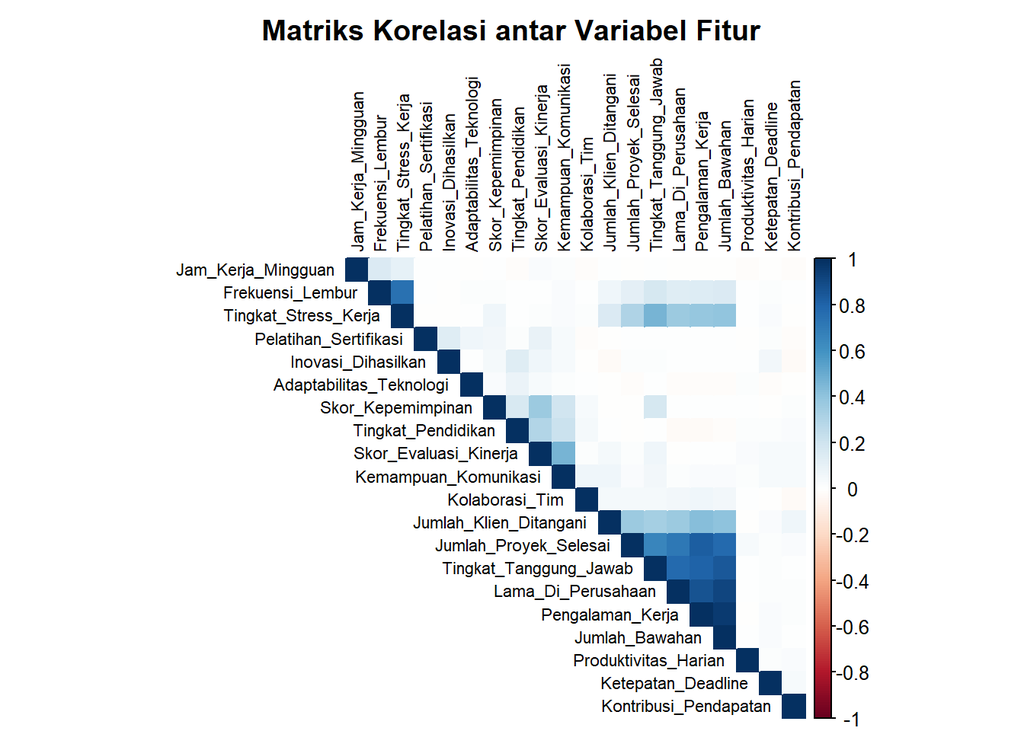

```r
library(ggplot2)
library(car)
library(corrplot)

# MATRIKS KORELASI ANTAR VARIABEL FITUR
variabel_fitur <- names(df)[names(df) != "Gaji_Bulanan"]
matriks_korelasi <- cor(df[, variabel_fitur])

# Identifikasi korelasi tinggi (>0.7)
korelasi_tinggi <- which(abs(matriks_korelasi) > 0.7 & upper.tri(matriks_korelasi), arr.ind = TRUE)
```

```r
# VARIANCE INFLATION FACTOR (VIF)
vif_values <- vif(model_A)

# Tampilkan VIF dalam tabel
vif_df <- data.frame(
  Variabel = names(vif_values),
  VIF = round(vif_values, 2),
  Kategori = ifelse(vif_values > 10, "🚩 Multikolinearitas TINGGI",
                   ifelse(vif_values > 5, "⚠️ Multikolinearitas Sedang", "✅ Aman"))
)

print(vif_df)
```

```
##                                        Variabel   VIF
## Tingkat_Pendidikan           Tingkat_Pendidikan  1.15
## Pengalaman_Kerja               Pengalaman_Kerja 13.74
## Pelatihan_Sertifikasi     Pelatihan_Sertifikasi  1.03
## Jam_Kerja_Mingguan           Jam_Kerja_Mingguan  1.04
## Jumlah_Proyek_Selesai     Jumlah_Proyek_Selesai  3.17
## Skor_Evaluasi_Kinerja     Skor_Evaluasi_Kinerja  1.51
## Jumlah_Bawahan                   Jumlah_Bawahan 20.84
## Lama_Di_Perusahaan           Lama_Di_Perusahaan  6.61
## Tingkat_Tanggung_Jawab   Tingkat_Tanggung_Jawab  4.25
## Frekuensi_Lembur               Frekuensi_Lembur  2.44
## Jumlah_Klien_Ditangani   Jumlah_Klien_Ditangani  1.24
## Skor_Kepemimpinan             Skor_Kepemimpinan  1.27
## Tingkat_Stress_Kerja       Tingkat_Stress_Kerja  3.01
## Produktivitas_Harian       Produktivitas_Harian  1.01
## Kemampuan_Komunikasi       Kemampuan_Komunikasi  1.31
## Inovasi_Dihasilkan           Inovasi_Dihasilkan  1.04
## Ketepatan_Deadline           Ketepatan_Deadline  1.01
## Kolaborasi_Tim                   Kolaborasi_Tim  1.01
## Adaptabilitas_Teknologi Adaptabilitas_Teknologi  1.01
## Kontribusi_Pendapatan     Kontribusi_Pendapatan  1.01
##                                           Kategori
## Tingkat_Pendidikan                         ✅ Aman
## Pengalaman_Kerja        🚩 Multikolinearitas TINGGI
## Pelatihan_Sertifikasi                      ✅ Aman
## Jam_Kerja_Mingguan                         ✅ Aman
## Jumlah_Proyek_Selesai                      ✅ Aman
## Skor_Evaluasi_Kinerja                      ✅ Aman
## Jumlah_Bawahan          🚩 Multikolinearitas TINGGI
## Lama_Di_Perusahaan      ⚠️ Multikolinearitas Sedang
## Tingkat_Tanggung_Jawab                     ✅ Aman
## Frekuensi_Lembur                           ✅ Aman
## Jumlah_Klien_Ditangani                     ✅ Aman
## Skor_Kepemimpinan                          ✅ Aman
## Tingkat_Stress_Kerja                       ✅ Aman
## Produktivitas_Harian                       ✅ Aman
## Kemampuan_Komunikasi                       ✅ Aman
## Inovasi_Dihasilkan                         ✅ Aman
## Ketepatan_Deadline                         ✅ Aman
## Kolaborasi_Tim                             ✅ Aman
## Adaptabilitas_Teknologi                    ✅ Aman
## Kontribusi_Pendapatan                      ✅ Aman
```

```r
# Statistik multikolinearitas
(multikol_tinggi <- sum(vif_values > 10))
```

```
## [1] 2
```

```r
(multikol_sedang <- sum(vif_values > 5 & vif_values <= 10))
```

```
## [1] 1
```

```r
(total_variabel <- length(vif_values))
```

```
## [1] 20
```

```
##
## _____SUMMARY MULTIKOLINEARITAS_____
```

```
## Variabel dengan VIF > 10 (Multikolinearitas Tinggi): 2/20 (10.0%)
```

```
## Variabel dengan VIF > 5 (Multikolinearitas Sedang):  1/20 (5.0%)
```

```
##
## 🚩 VARIABEL DENGAN MULTIKOLINEARITAS TINGGI (VIF > 10):
##     Pengalaman_Kerja (VIF = 13.74)
##     Jumlah_Bawahan (VIF = 20.84)
```

```
##
## _____KESIMPULAN_____
```

```
## ❌ MASALAH MULTIKOLINEARITAS TERDETEKSI:
##    - Koefisien regresi menjadi TIDAK STABIL
##    - Interpretasi pengaruh individual variabel TIDAK ANDAL
##    - Perubahan kecil dalam data menyebabkan perubahan BESAR dalam estimasi
##    - Standar error membesar, uji signifikansi menjadi TIDAK VALID
```

2. **Perilaku Sisaan (Error):** Analisis sisaan dari Model A untuk memverifikasi apakah perilakunya sesuai dengan asumsi yang mendasari sebuah model linier yang valid. Sajikan bukti visual dan jelaskan dampaknya terhadap validitas uji signifikansi (uji-t dan uji-F) dari model Anda.

```r
library(ggplot2)
library(lmtest)
library(nortest)
library(car)

# Mendapatkan residual dan fitted values
residuals_model_A <- residuals(model_A)
fitted_model_A <- fitted(model_A)

# UJI NORMALITAS RESIDUAL
# Shapiro-Wilk Test untuk normalitas
(shapiro_test <- shapiro.test(residuals_model_A))
```

```
##
##  Shapiro-Wilk normality test
##
## data:  residuals_model_A
## W = 0.99492, p-value = 1.172e-09
```

```
## Kesimpulan: Residual TIDAK berdistribusi normal ❌
```

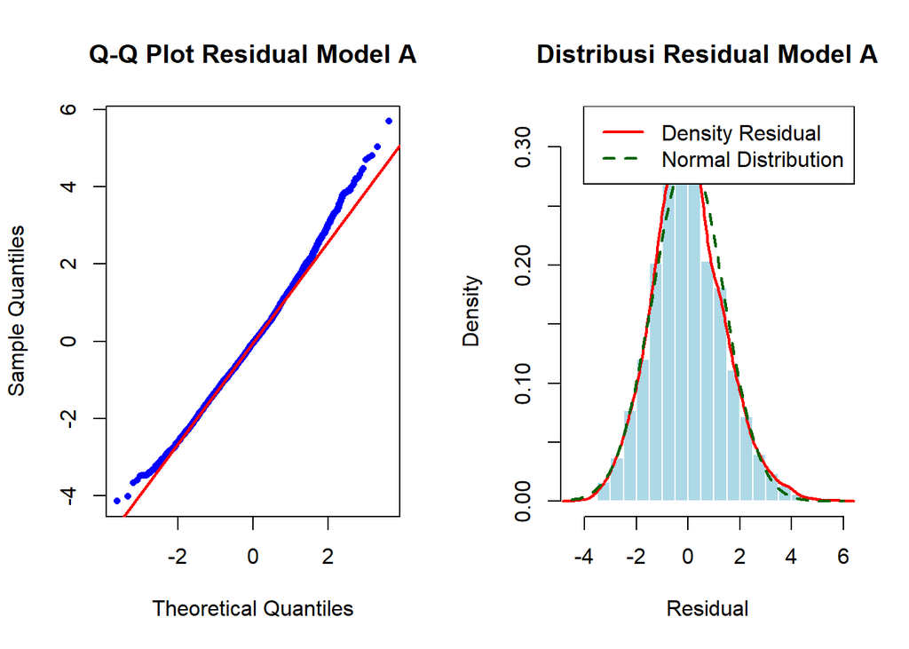

```r
# Visualisasi Normalitas Residual
par(mfrow = c(1, 2))

# Q-Q Plot
qqnorm(residuals_model_A, main = "Q-Q Plot Residual Model A",
       col = "blue", pch = 16, cex = 0.7)
qqline(residuals_model_A, col = "red", lwd = 2)

# Histogram dengan density curve
hist(residuals_model_A, breaks = 30, col = "lightblue",
     main = "Distribusi Residual Model A",
     xlab = "Residual", probability = TRUE, border = "white")
lines(density(residuals_model_A), col = "red", lwd = 2)
curve(dnorm(x, mean = mean(residuals_model_A), sd = sd(residuals_model_A)),
      col = "darkgreen", lwd = 2, lty = 2, add = TRUE)
legend("topright", legend = c("Density Residual", "Normal Distribution"),
       col = c("red", "darkgreen"), lwd = 2, lty = c(1,2))
```

```r
par(mfrow = c(1, 1))

# UJI HOMOSKEDASTISITAS
# Breusch-Pagan Test untuk homoskedastisitas
(bp_test <- bptest(model_A))
```

```
##
##  studentized Breusch-Pagan test
##
## data:  model_A
## BP = 28.475, df = 20, p-value = 0.09863
```

```
## Kesimpulan: Homoskedastisitas terpenuhi ✅
```

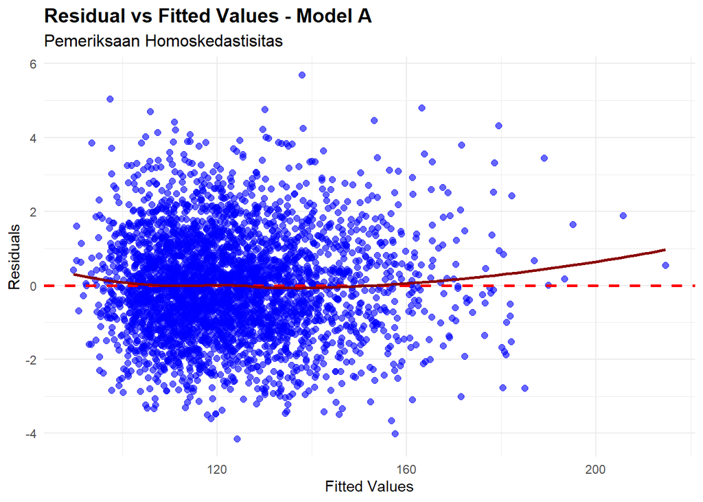

```r
# Visualisasi Homoskedastisitas
ggplot(data = data.frame(Fitted = fitted_model_A, Residuals = residuals_model_A),
       aes(x = Fitted, y = Residuals)) +
  geom_point(alpha = 0.6, color = "blue", size = 2) +
  geom_hline(yintercept = 0, linetype = "dashed", color = "red", size = 1) +
  geom_smooth(method = "loess", color = "darkred", se = FALSE, size = 1) +
  labs(title = "Residual vs Fitted Values - Model A",
       subtitle = "Pemeriksaan Homoskedastisitas",
       x = "Fitted Values", y = "Residuals") +
  theme_minimal() +
  theme(plot.title = element_text(face = "bold", size = 14),
        plot.subtitle = element_text(size = 12))
```

```r
# UJI AUTOKORELASI
# Durbin-Watson Test untuk autokorelasi
(dw_test <- dwtest(model_A))
```

```
##
##  Durbin-Watson test
##
## data:  model_A
## DW = 0.31513, p-value < 2.2e-16
## alternative hypothesis: true autocorrelation is greater than 0
```

```r
# Interpretasi Durbin-Watson yang benar
dw_stat <- dw_test$statistic
```

```
## Kesimpulan: Terdapat AUTOKORELASI POSITIF  ❌
```

```
## _____RESUME DIAGNOSTIK MODEL A_____
```

```
##                Asumsi       Status                        Dampak_Pada_Uji
## 1 Normalitas Residual ❌ DILANGGAR              Validitas Uji-t dan Uji-F
## 2   Homoskedastisitas ✅ TERPENUHI Efisiensi estimator dan standard error
## 3        Autokorelasi ❌ DILANGGAR  Validitas Uji-F dan estimasi variance
```